# ST 558 Project 1

Eric Warren and Chandler Ellsworth

2023-09-12

# Data Processing

## First Data Set

The first thing we are going to do is read in a section of the data that we are going to analyze and use to make function. The code we are using was given to us so we had the opportunity to access this data.

```r
library(readr)
library(tidyverse)

sheet1 <- read_csv("https://www4.stat.ncsu.edu/~online/datasets/EDU01a.csv")
```

Now we are going to filter the duplicate row and select the following columns in order to trim the data we are analyzing. The columns we are using have at least one of the following characteristics: * `Area_name` (which we will rename as `area_name`) * `STCOU` * Any column that ends in “D”

```r
sheet1 <- sheet1 %>%
  filter(Area_name != "District of Columbia") %>%
  dplyr::select(Area_name, STCOU, ends_with("D")) %>%
  rename(area_name = Area_name)

sheet1
```

```
## # A tibble: 3,197 × 12
##    area_name     STCOU EDU010187D EDU010188D EDU010189D EDU010190D EDU010191D
##    <chr>         <chr>      <dbl>      <dbl>      <dbl>      <dbl>      <dbl>
##  1 UNITED STATES 00000   40024299   39967624   40317775   40737600   41385442
##  2 ALABAMA       01000     733735     728234     730048     728252     725541
##  3 Autauga, AL   01001       6829       6900       6920       6847       7008
##  4 Baldwin, AL   01003      16417      16465      16799      17054      17479
##  5 Barbour, AL   01005       5071       5098       5068       5156       5173
##  6 Bibb, AL      01007       3557       3508       3571       3621       3652
##  7 Blount, AL    01009       7319       7223       7205       7209       7155
##  8 Bullock, AL   01011       2014       1980       1985       1983       1985
##  9 Butler, AL    01013       4640       4582       4610       4591       4544
## 10 Calhoun, AL   01015      20939      20923      20907      20849      20768
## # ℹ 3,187 more rows
## # ℹ 5 more variables: EDU010192D <dbl>, EDU010193D <dbl>, EDU010194D <dbl>,
## #   EDU010195D <dbl>, EDU010196D <dbl>
```

Now we can see how our data is structured. We can see that it is categorized with the country overall statistics first, then the state, and lastly county level data.

Now we are going to convert the data into a *long format* where each row will have the `area_name` with only one enrollment value.

```r
sheet1_long <- sheet1 %>%
  pivot_longer(
    cols = ends_with("D"),
    names_to = "education_measurement",
    values_to = "enrollment")

sheet1_long
```

```
## # A tibble: 31,970 × 4
##    area_name     STCOU education_measurement enrollment
##    <chr>         <chr> <chr>                      <dbl>
##  1 UNITED STATES 00000 EDU010187D              40024299
##  2 UNITED STATES 00000 EDU010188D              39967624
##  3 UNITED STATES 00000 EDU010189D              40317775
##  4 UNITED STATES 00000 EDU010190D              40737600
##  5 UNITED STATES 00000 EDU010191D              41385442
##  6 UNITED STATES 00000 EDU010192D              42088151
##  7 UNITED STATES 00000 EDU010193D              42724710
##  8 UNITED STATES 00000 EDU010194D              43369917
##  9 UNITED STATES 00000 EDU010195D              43993459
## 10 UNITED STATES 00000 EDU010196D              44715737
## # ℹ 31,960 more rows
```

We have now changed the data into a longer format where only one education measurement is in each row and its corresponding value is highlighted in the next column.

Now we are going to parse the `education_measurement` column to first have the type of survey which is the first three letters followed by the next four digits and then also pull the year from the third to last and second to last elements in the string. We will be using the `substr()` function to do this. Lastly, we are going to use the `dplyr::select()` and `everything()` functions to reorder the columns to make it easier to follow. This part is our personal preference.

```r
# Now get the year from the education_measurement column
sheet1_long$year <- substr(sheet1_long$education_measurement,
                                 start = nchar(sheet1_long$education_measurement)-2,
                                 stop = nchar(sheet1_long$education_measurement)-1)

sheet1_long$year <- as.numeric(sheet1_long$year)
# This allows us to make sure the survey was done in 1900s or 2000s
sheet1_long$year <- ifelse(sheet1_long$year > 25, 1900 + sheet1_long$year, 2000 + sheet1_long$year)


# Now get the first 3 letters and next 4 digits to see what type of survey was taken
sheet1_long$education_measurement <- substr(sheet1_long$education_measurement,
                                            start = 1,
                                            stop = 7)

# Order the data to get the year in front of the measurement
sheet1_long <- sheet1_long %>%
  dplyr::select(area_name, STCOU, year, everything())

# Display this new data
sheet1_long
```

```
## # A tibble: 31,970 × 5
##    area_name     STCOU  year education_measurement enrollment
##    <chr>         <chr> <dbl> <chr>                      <dbl>
##  1 UNITED STATES 00000  1987 EDU0101                 40024299
##  2 UNITED STATES 00000  1988 EDU0101                 39967624
##  3 UNITED STATES 00000  1989 EDU0101                 40317775
##  4 UNITED STATES 00000  1990 EDU0101                 40737600
##  5 UNITED STATES 00000  1991 EDU0101                 41385442
##  6 UNITED STATES 00000  1992 EDU0101                 42088151
##  7 UNITED STATES 00000  1993 EDU0101                 42724710
##  8 UNITED STATES 00000  1994 EDU0101                 43369917
##  9 UNITED STATES 00000  1995 EDU0101                 43993459
## 10 UNITED STATES 00000  1996 EDU0101                 44715737
## # ℹ 31,960 more rows
```

Now we can see that our data has the year and the type of survey (or measurement of education) that was taken for corresponding areas. We now want to separate the data into two different tibbles. The first is one on a county level, which will be called `sheet1_county_data` and the other which is not county level data, which will be called `sheet1_not_county_data`. We will use the `filter()` and `grepl()` functions to find the pattern of “County Name, DD” to make that a part of `sheet1_county_data` and data that is not a part of this pattern a part of `sheet1_not_county_data`. We are also going to create a class called “county” for `sheet1_county_data` and a class called “state” for `sheet1_not_county_data`.

```r
# Here we are going to make the county level data
sheet1_county_data <- sheet1_long %>%
  filter(grepl(pattern = ", \\w\\w", area_name))
# Create the new class called county
class(sheet1_county_data) <- c("county", class(sheet1_county_data))
sheet1_county_data
```

```
## # A tibble: 31,450 × 5
##    area_name   STCOU  year education_measurement enrollment
##    <chr>       <chr> <dbl> <chr>                      <dbl>
##  1 Autauga, AL 01001  1987 EDU0101                     6829
##  2 Autauga, AL 01001  1988 EDU0101                     6900
##  3 Autauga, AL 01001  1989 EDU0101                     6920
##  4 Autauga, AL 01001  1990 EDU0101                     6847
##  5 Autauga, AL 01001  1991 EDU0101                     7008
##  6 Autauga, AL 01001  1992 EDU0101                     7137
##  7 Autauga, AL 01001  1993 EDU0101                     7152
##  8 Autauga, AL 01001  1994 EDU0101                     7381
##  9 Autauga, AL 01001  1995 EDU0101                     7568
## 10 Autauga, AL 01001  1996 EDU0101                     7834
## # ℹ 31,440 more rows
```

```r
# Here we are going to make the non-county level data
sheet1_not_county_data <- sheet1_long %>%
  filter(!grepl(pattern = ", \\w\\w", area_name))
# Create the new class called state
class(sheet1_not_county_data) <- c("state", class(sheet1_not_county_data))
sheet1_not_county_data
```

```
## # A tibble: 520 × 5
##    area_name     STCOU  year education_measurement enrollment
##    <chr>         <chr> <dbl> <chr>                      <dbl>
##  1 UNITED STATES 00000  1987 EDU0101                 40024299
##  2 UNITED STATES 00000  1988 EDU0101                 39967624
##  3 UNITED STATES 00000  1989 EDU0101                 40317775
##  4 UNITED STATES 00000  1990 EDU0101                 40737600
##  5 UNITED STATES 00000  1991 EDU0101                 41385442
##  6 UNITED STATES 00000  1992 EDU0101                 42088151
##  7 UNITED STATES 00000  1993 EDU0101                 42724710
##  8 UNITED STATES 00000  1994 EDU0101                 43369917
##  9 UNITED STATES 00000  1995 EDU0101                 43993459
## 10 UNITED STATES 00000  1996 EDU0101                 44715737
## # ℹ 510 more rows
```

After seeing how our two datasets look, we are going to add to the `sheet1_county_data` tibble by creating a new variable called `state` which shows what state each county is in. We are going to use the `substr()` function to do this. Lastly using `dplyr::select()` and `everything()` functions, we are going to reorder the columns for them to make sense.

```r
# Get the state from each county and make it a new column
sheet1_county_data$state <- substr(sheet1_county_data$area_name,
                                   start = nchar(sheet1_county_data$area_name)-1,
                                   stop = nchar(sheet1_county_data$area_name))

# Reorder the columns with county and then state column following it
sheet1_county_data <- sheet1_county_data %>%
  dplyr::select(area_name, state, everything())

# Show the updated tibble
sheet1_county_data
```

```
## # A tibble: 31,450 × 6
##    area_name   state STCOU  year education_measurement enrollment
##    <chr>       <chr> <chr> <dbl> <chr>                      <dbl>
##  1 Autauga, AL AL    01001  1987 EDU0101                     6829
##  2 Autauga, AL AL    01001  1988 EDU0101                     6900
##  3 Autauga, AL AL    01001  1989 EDU0101                     6920
##  4 Autauga, AL AL    01001  1990 EDU0101                     6847
##  5 Autauga, AL AL    01001  1991 EDU0101                     7008
##  6 Autauga, AL AL    01001  1992 EDU0101                     7137
##  7 Autauga, AL AL    01001  1993 EDU0101                     7152
##  8 Autauga, AL AL    01001  1994 EDU0101                     7381
##  9 Autauga, AL AL    01001  1995 EDU0101                     7568
## 10 Autauga, AL AL    01001  1996 EDU0101                     7834
## # ℹ 31,440 more rows
```

With adding the state to the `sheet1_county_data` tibble, we now want to add the division of the states to the `sheet1_not_county_data`, which we will call `division`. The divisions will be created based on the [Census Bureau](https://en.wikipedia.org/wiki/List_of_regions_of_the_United_States). This new variable will be created by using the `%in%` operator. If the division does not correspond to a state, we want to return **“Error”** so we know it is not a US state. Lastly using `dplyr::select()` and `everything()` functions, we are going to reorder the columns for them to make sense.

```r
# Make all the divisions based on classification
division_1 <- toupper(c("Connecticut", "Maine", "Massachusetts", "New Hampshire", "Rhode Island", "Vermont"))
division_2 <- toupper(c("New Jersey", "New York", "Pennsylvania"))
division_3 <- toupper(c("Illinois", "Indiana", "Michigan", "Ohio", "Wisconsin"))
division_4 <- toupper(c("Iowa", "Kansas", "Minnesota", "Missouri", "Nebraska", "North Dakota", "South Dakota"))
division_5 <- toupper(c("Delaware", "Florida", "Georgia", "Maryland", "North Carolina", "South Carolina", "Virginia",
                        "District of Columbia", "West Virginia"))
division_6 <- toupper(c("Alabama", "Kentucky", "Mississippi", "Tennessee"))
division_7 <- toupper(c("Arkansas", "Louisiana", "Oklahoma", "Texas"))
division_8 <- toupper(c("Arizona", "Colorado", "Idaho", "Montana", "Nevada", "New Mexico", "Utah", "Wyoming"))
division_9 <- toupper(c("Alaska", "California", "Hawaii", "Oregon", "Washington"))

# Create a new column called division to put the states in the correct spot. We will then sort the data so the division is next to the state
sheet1_not_county_data <- sheet1_not_county_data %>%
  mutate(
    division = ifelse(
      area_name %in% division_1, "New England", ifelse(
        area_name %in% division_2, "Middle Atlantic", ifelse(
          area_name %in% division_3, "East North Central", ifelse(
            area_name %in% division_4, "West North Central", ifelse(
              area_name %in% division_5, "South Atlantic", ifelse(
                area_name %in% division_6, "East South Central", ifelse(
                  area_name %in% division_7, "West South Central", ifelse(
                    area_name %in% division_8, "Mountain", ifelse(
                      area_name %in% division_9, "Pacific", "ERROR"
                    )
                  )
                )
              )
            )
          )
        )
      )
    )
  ) %>%
  dplyr::select(area_name, division, everything())

# Print the updated tibble
sheet1_not_county_data
```

```
## # A tibble: 520 × 6
##    area_name     division STCOU  year education_measurement enrollment
##    <chr>         <chr>    <chr> <dbl> <chr>                      <dbl>
##  1 UNITED STATES ERROR    00000  1987 EDU0101                 40024299
##  2 UNITED STATES ERROR    00000  1988 EDU0101                 39967624
##  3 UNITED STATES ERROR    00000  1989 EDU0101                 40317775
##  4 UNITED STATES ERROR    00000  1990 EDU0101                 40737600
##  5 UNITED STATES ERROR    00000  1991 EDU0101                 41385442
##  6 UNITED STATES ERROR    00000  1992 EDU0101                 42088151
##  7 UNITED STATES ERROR    00000  1993 EDU0101                 42724710
##  8 UNITED STATES ERROR    00000  1994 EDU0101                 43369917
##  9 UNITED STATES ERROR    00000  1995 EDU0101                 43993459
## 10 UNITED STATES ERROR    00000  1996 EDU0101                 44715737
## # ℹ 510 more rows
```

## Second Data Set

Now we want to repeat this process with using functions that we are going to create. Before we do that, we are going to do is read in our next section of data that we are going to analyze and use to make function. The code we are using is done the same procedure to read in the first section of data that was used in the previous section.

```r
sheet2 <- read_csv("https://www4.stat.ncsu.edu/~online/datasets/EDU01b.csv")
```

Now we are going to start making our functions to that did all the previous things we were asked to do for our first set of data. The first function we are going to create called `reshaping_data()` will dplyr::select the columns we need and then pivot the data into the longer format, like what was done in the previous section. We are also going to remove the duplicate row for the **“District of Columbia”**

```r
reshaping_data <- function(tibble, value_column = "enrollment") {
  # Here we are selecting and renaming our desired columns
  tibble <- tibble %>%
    filter(Area_name != "District of Columbia") %>%
    dplyr::select(Area_name, STCOU, ends_with("D")) %>%
    rename(area_name = Area_name)

  # Here we are changing our data into the long format
  tibble_long <- tibble %>%
  pivot_longer(
    cols = ends_with("D"),
    names_to = "education_measurement",
    values_to = value_column)
  # Now we are going to return the long formatted data
  return(tibble_long)
}
```

Now we want to create another function, which will be called `find_year_and_survey()`. This function will allow us to parse the `education_measurement` column to first have the type of survey which is the first three letters followed by the next four digits and then also pull the year from the third to last and second to last elements in the string. We will be using the `substr()` function within our newly created function to do this. Lastly, we are going to use the `dplyr::select()` and `everything()` functions within our function to reorder the columns to make it easier to follow. This part is our personal preference, as we did before with the first data set.

```r
find_year_and_survey <- function(tibble_long) {
  # Now get the year from the education_measurement column
  tibble_long$year <- substr(tibble_long$education_measurement,
                              start = nchar(tibble_long$education_measurement)-2,
                              stop = nchar(tibble_long$education_measurement)-1)
  tibble_long$year <- as.numeric(tibble_long$year)
  # This allows us to make sure the survey was done in 1900s or 2000s
  tibble_long$year <- ifelse(tibble_long$year > 25, 1900 + tibble_long$year, 2000 + tibble_long$year)

  # Now get the first 3 letters and next 4 digits to see what type of survey was taken
  tibble_long$education_measurement <- substr(tibble_long$education_measurement,
                                              start = 1,
                                              stop = 7)

  # Order the data to get the year in front of the measurement
  tibble_long <- tibble_long %>%
    dplyr::select(area_name, STCOU, year, everything())

  # Return this new data
  return(tibble_long)
}
```

Now for the county-level tibble, we are going to create a function called `find_state()` which will allow us to create a new variable called `state` that describes which state one of these county measurements corresponds to using `substr()` within our function. We are also going to reorder the columns to put the new `state` variable next to the `area_name` or county of that state.

```r
find_state <- function(tibble_county_data) {
  # Get the state from each county and make it a new column
  tibble_county_data$state <- substr(tibble_county_data$area_name,
                                     start = nchar(tibble_county_data$area_name)-1,
                                     stop = nchar(tibble_county_data$area_name))

  # Reorder the columns with county and then state column following it
  tibble_county_data <- tibble_county_data %>%
    dplyr::select(area_name, state, everything())

  # Show the updated tibble
  return(tibble_county_data)
}
```

Now for the non-county-level tibble, we are going to create a function called `find_division()` which will allow us to create a new variable called `division`, which is based on the US divisions defined by the [Census Bureau](https://en.wikipedia.org/wiki/List_of_regions_of_the_United_States). This new variable will be created by using the `%in%` operator. If the division does not correspond to a state, we want to return **“Error”** so we know it is not a US state. Lastly using `dplyr::select()` and `everything()` functions within our function, we are going to reorder the columns for them to make sense.

```r
find_division <- function(tibble_non_county_data) {
  # Make all the divisions based on classification
  division_1 <- toupper(c("Connecticut", "Maine", "Massachusetts", "New Hampshire", "Rhode Island", "Vermont"))
  division_2 <- toupper(c("New Jersey", "New York", "Pennsylvania"))
  division_3 <- toupper(c("Illinois", "Indiana", "Michigan", "Ohio", "Wisconsin"))
  division_4 <- toupper(c("Iowa", "Kansas", "Minnesota", "Missouri", "Nebraska", "North Dakota", "South Dakota"))
  division_5 <- toupper(c("Delaware", "Florida", "Georgia", "Maryland", "North Carolina", "South Carolina", "Virginia",
                          "District of Columbia", "West Virginia"))
  division_6 <- toupper(c("Alabama", "Kentucky", "Mississippi", "Tennessee"))
  division_7 <- toupper(c("Arkansas", "Louisiana", "Oklahoma", "Texas"))
  division_8 <- toupper(c("Arizona", "Colorado", "Idaho", "Montana", "Nevada", "New Mexico", "Utah", "Wyoming"))
  division_9 <- toupper(c("Alaska", "California", "Hawaii", "Oregon", "Washington"))

  # Create a new column called division to put the states in the correct spot. We will then sort the data so the division is next to the state
  tibble_non_county_data <- tibble_non_county_data %>%
    mutate(division = ifelse(
      area_name %in% division_1, "New England", ifelse(
        area_name %in% division_2, "Middle Atlantic", ifelse(
          area_name %in% division_3, "East North Central", ifelse(
            area_name %in% division_4, "West North Central", ifelse(
              area_name %in% division_5, "South Atlantic", ifelse(
                area_name %in% division_6, "East South Central", ifelse(
                  area_name %in% division_7, "West South Central", ifelse(
                    area_name %in% division_8, "Mountain", ifelse(
                      area_name %in% division_9, "Pacific", "ERROR"
                      )
                    )
                  )
                )
              )
            )
          )
        )
      )
    ) %>%
    dplyr::select(area_name, division, everything())
  # Return the updated tibble
  return(tibble_non_county_data)
}
```

Our next function will allow us to split the data into two different tibbles, one based on county-level data and the other by non-county-level data, similar to what we did with the first data source. We are going to call this function `split_into_level_type()`. We are also going to combine our last two created functions with this one to return the two correctly structured data sets we desire.

```r
split_into_level_type <- function(tibble_long) {
  # Here we are going to split our data into county level and non-county level data
  # First split into county level data
  tibble_county_data <- tibble_long %>%
    filter(grepl(pattern = ", \\w\\w", area_name))
  # Create the new class called county
  class(tibble_county_data) <- c("county", class(tibble_county_data))

  # Here we are going to make the non-county level data
  tibble_non_county_data <- tibble_long %>%
    filter(!grepl(pattern = ", \\w\\w", area_name))
   # Create the new class called state
  class(tibble_non_county_data) <- c("state", class(tibble_non_county_data))

  # Now combine our county-level function from before to get the state
  tibble_county_data_updated <- find_state(tibble_county_data)

  # Now combine our non-county-level function from before to get the division
  tibble_non_county_data_updated <- find_division(tibble_non_county_data)

  # Return the two tibbles
  return(list(county = tibble_county_data_updated, state = tibble_non_county_data_updated))
}
```

Now the last thing we are going to do is put all the functions into one function call. This will allow us to call only one function to get all the things we want with a URL we are reading in for our data. We are going to call this function `wrapping_data_processing_functions()`.

```r
wrapping_data_processing_functions <- function(url, var_name = "enrollment") {
  # Read in the data through the URL
  tibble <- read_csv(url)

  # Now reshape the tibble with how we want it to look with columns selected and removing the duplicate row
  tibble_long <- reshaping_data(tibble, value_column = var_name)

  # Now we want to find the year and survey type of the data
  tibble_long_updated <- find_year_and_survey(tibble_long)

  # Lastly we want to split the data into county and non-county (state) level data and include necessary information
  tibble_education_data_list <- split_into_level_type(tibble_long_updated)

  # Return the final list of two tibbles
  return(tibble_education_data_list)
}
```

```r
combine_census <- function(wrapper1, wrapper2) {
  county_data_merge <- dplyr::bind_rows(wrapper1[["county"]], wrapper2[["county"]])
  non_county_data_merge <- dplyr::bind_rows(wrapper1[["state"]], wrapper2[["state"]])

  return(list(county = county_data_merge, state = non_county_data_merge))
}
```

```r
plot.state <- function(df, var_name = "enrollment") {
  new_df <- df %>%
    group_by(division, year) %>%
    summarise(avg_enrollment = mean(get(var_name))) %>%
    filter(division != "ERROR")

  ggplot(new_df, aes(x = year, y = avg_enrollment, color = division)) +
    geom_line()
}
```

```r
plot.county <- function(df, var_name = "enrollment", filter_state = "AL", filter_county = "top", filter_value = 5) {

filter_multiplier <- ifelse(filter_county == "top", 1,
                            ifelse(filter_county == "bottom", 0,
                                   stop("Must select either 'top' or 'bottom' as options for filter_county; default is 'top'")))

 new_df <- df %>%
    filter(state == filter_state) %>%
    group_by(area_name) %>%
    summarise(avg_enrollment = mean(get(var_name))) %>%
    arrange(if_else((avg_enrollment * filter_multiplier) > 0, desc(avg_enrollment), avg_enrollment)) %>%
    slice(1:filter_value)

 filtered_df <- df %>%
   filter((state == filter_state) & (area_name %in% new_df$area_name))

 ggplot(filtered_df, aes(x = year, y = get(var_name), color = area_name)) +
   geom_line()
}
```

```r
wrapper1 <- wrapping_data_processing_functions("https://www4.stat.ncsu.edu/~online/datasets/EDU01a.csv",
                                               var_name = "enrollment")
wrapper2 <- wrapping_data_processing_functions("https://www4.stat.ncsu.edu/~online/datasets/EDU01b.csv",
                                               var_name = "enrollment")

data_combine <- combine_census(wrapper1, wrapper2)
```

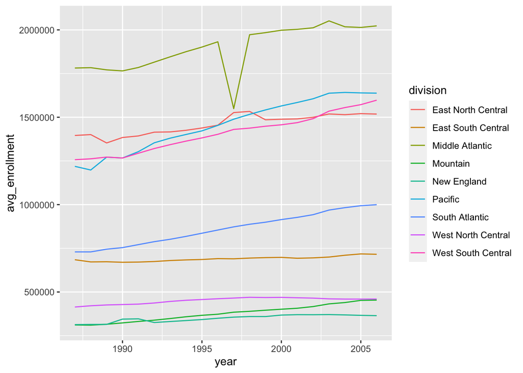

```r
plot(data_combine[["state"]])
```

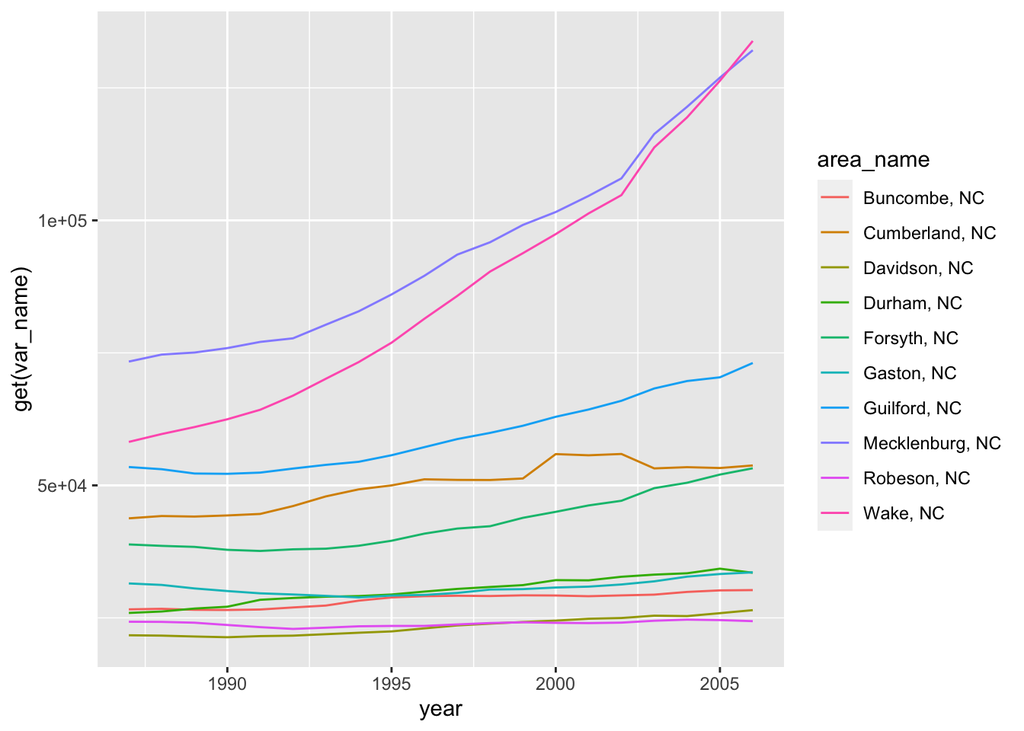

```r
plot(data_combine[["county"]], filter_state = "NC", filter_county = "top", filter_value = 10)
```

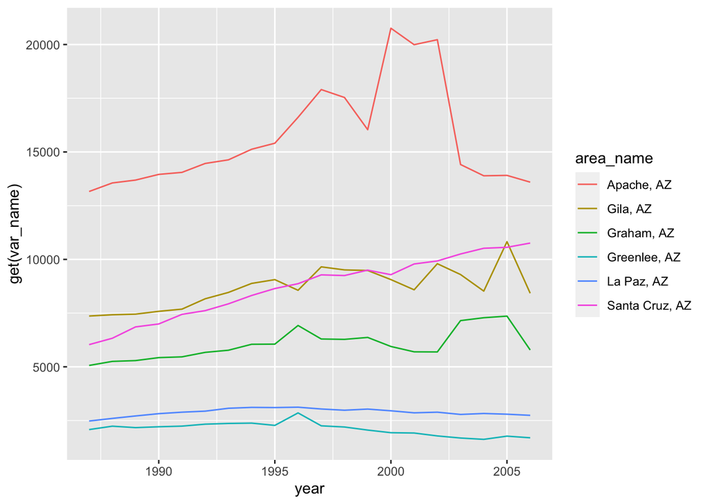

```r
plot(data_combine[["county"]], filter_state = "AZ", filter_county = "bottom", filter_value = 6)
```

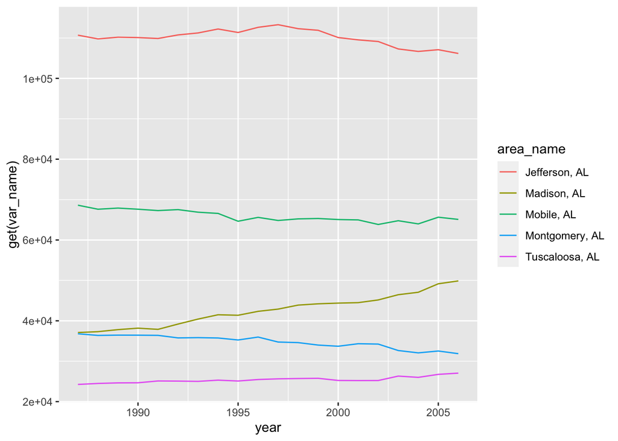

```r
plot(data_combine[["county"]])
```

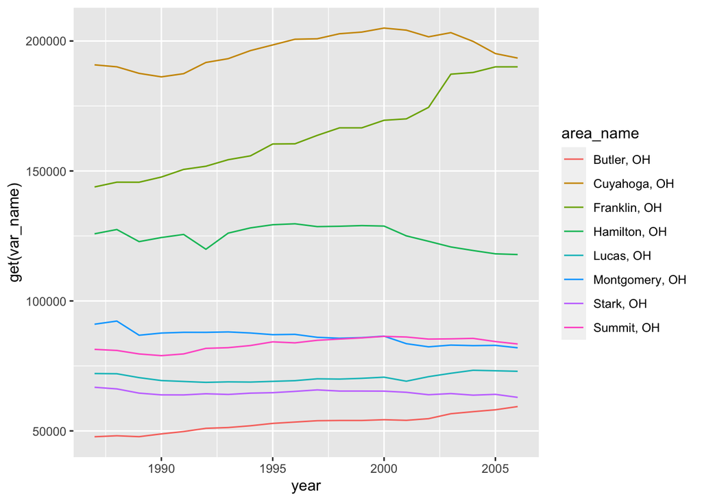

```r
plot(data_combine[["county"]], filter_state = "OH", filter_county = "top", filter_value = 8)
```

```r
wrapper3 <- wrapping_data_processing_functions("https://www4.stat.ncsu.edu/~online/datasets/PST01a.csv",
                                               var_name = "enrollment")
wrapper4 <- wrapping_data_processing_functions("https://www4.stat.ncsu.edu/~online/datasets/PST01b.csv",
                                               var_name = "enrollment")
wrapper5 <- wrapping_data_processing_functions("https://www4.stat.ncsu.edu/~online/datasets/PST01c.csv",
                                               var_name = "enrollment")
wrapper6 <- wrapping_data_processing_functions("https://www4.stat.ncsu.edu/~online/datasets/PST01d.csv",
                                               var_name = "enrollment")

data_combine2 <- combine_census(wrapper3, wrapper4)
data_combine3 <- combine_census(data_combine2, wrapper5)
data_combine4 <- combine_census(data_combine3, wrapper6)
```

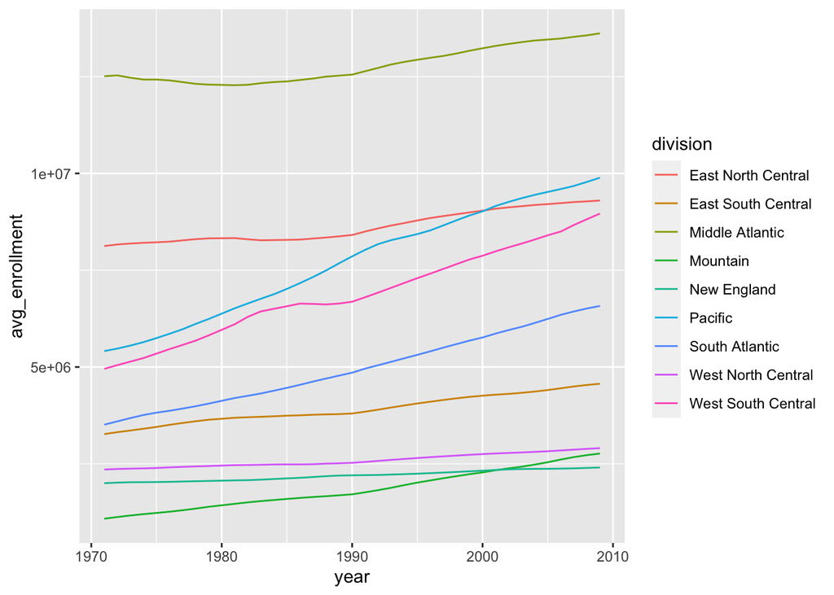

```r
plot(data_combine4[["state"]])
```

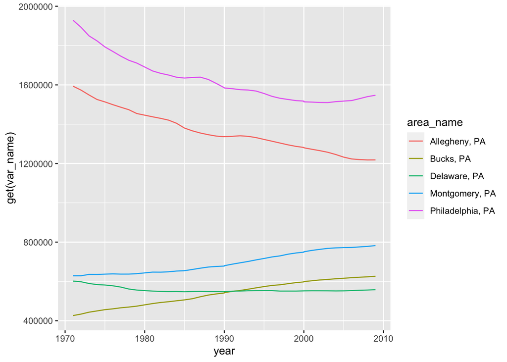

```r
plot(data_combine4[["county"]], filter_state = "PA", filter_county = "top", filter_value = 5)
```

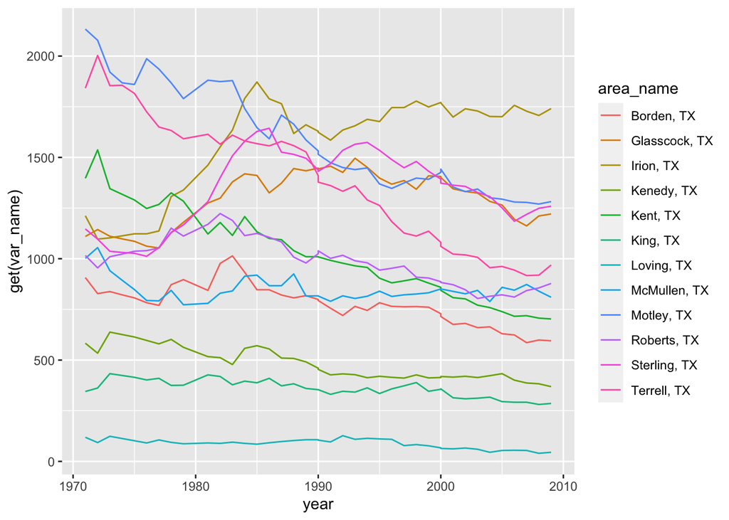

```r
plot(data_combine4[["county"]], filter_state = "TX", filter_county = "bottom", filter_value = 12)
```

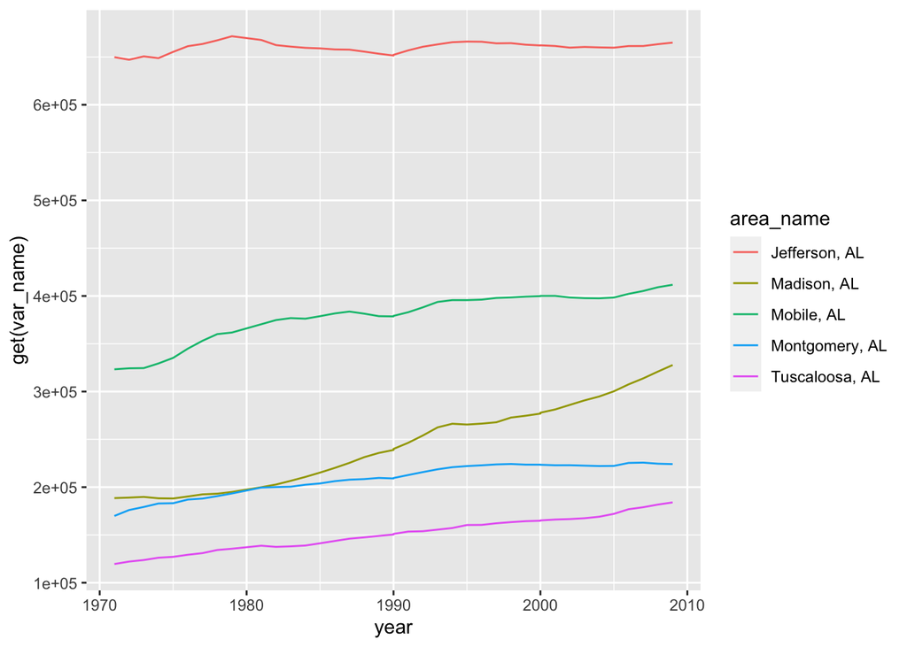

```r
plot(data_combine4[["county"]])
```

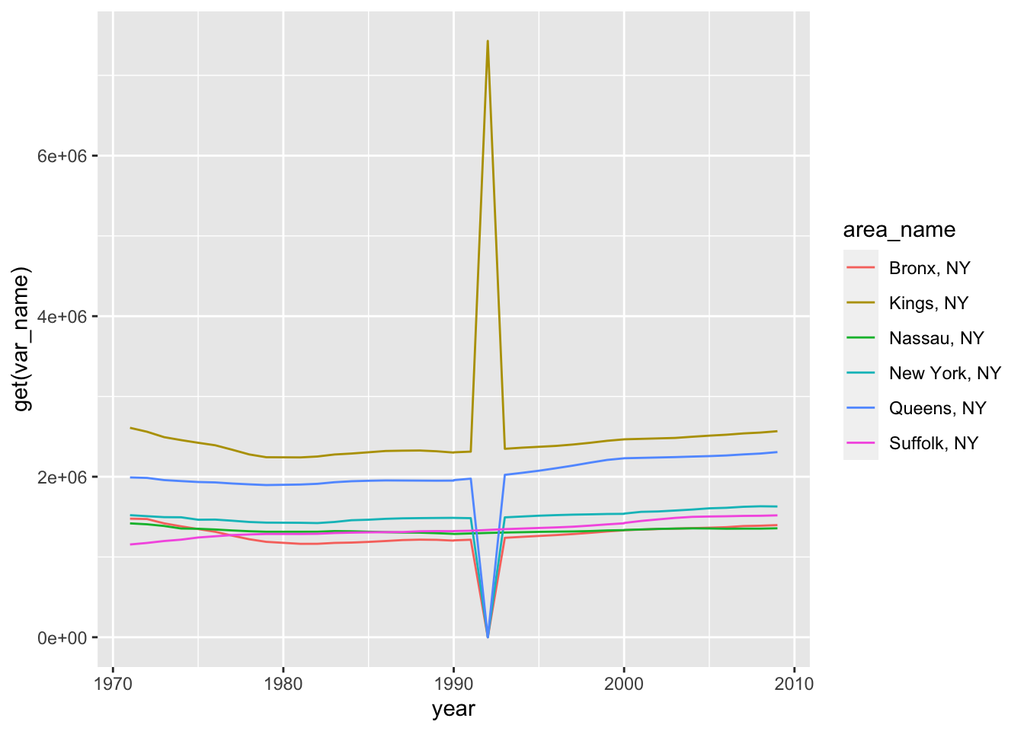

```r
plot(data_combine4[["county"]], filter_state = "NY", filter_county = "top", filter_value = 6)
```